# Glycoprotein C / Pre-glycoprotein polyprotein GP complex

Fold-switch pair **3mkoA_5ineA** — **3mkoA** vs **5ineA**

Mammarenavirus choriomeningitidis

## Figure 1: Phylogenetic tree with per-cluster fold-preference heatmap.

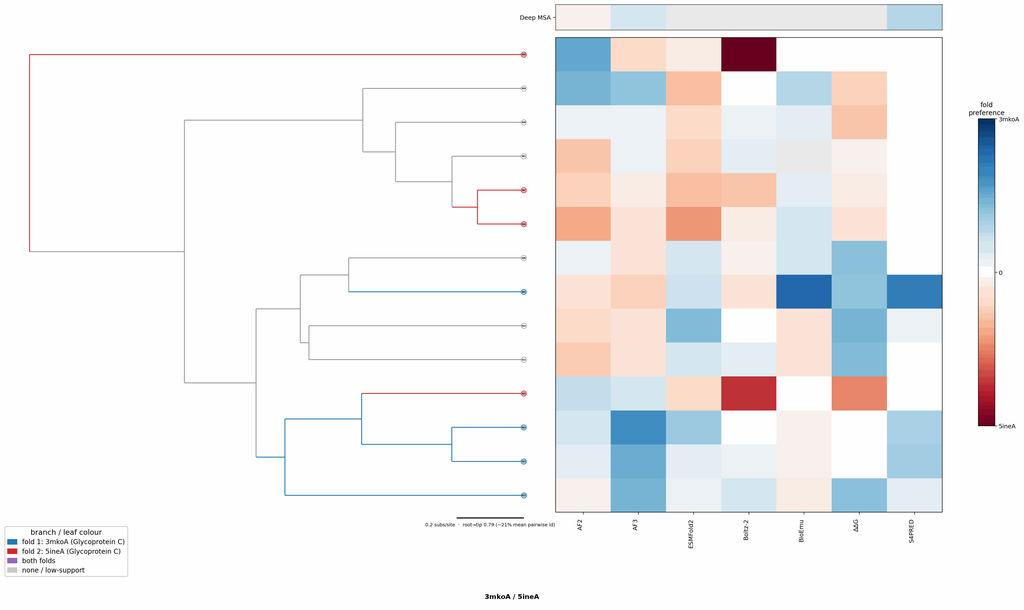

## Figure 2: Aligned overlay (both folds superposed)

The single fold-switching chain of each fold superposed by TM-align; waters hidden, any ligand shown as green sticks. Grey = structurally conserved core, colour = divergent (fold-switching) region.

3mkoA (Glycoprotein C / Pre-glycoprotein polyprotein GP complex)5ineA (Glycoprotein C / Pre-glycoprotein polyprotein GP complex)Ligand IUM (bound to 3mkoA), Ligand BMA|MAN|NAG (bound to 5ineA)

TM-score: 0.050 · Trigger class: mutation

Aligned overlay

Loading...

## Figure 3: The two folds, side by side

Each fold is coloured by per-residue Cα deviation between the two superposed structures: grey ≈ conserved core, full colour = structurally divergent (fold-switching) region.

3mkoA (Glycoprotein C / Pre-glycoprotein polyprotein GP complex)

5ineA (Glycoprotein C / Pre-glycoprotein polyprotein GP complex)

0 Å5≥10 Å

3mkoA (Glycoprotein C / Pre-glycoprotein polyprotein GP complex)

Loading...

5ineA (Glycoprotein C / Pre-glycoprotein polyprotein GP complex)

Loading...

## Figure 4: Best-cluster predicted contact maps over the two true folds.

Predicted contact maps (MSA-Transformer) for the clusters best matching each fold, over the true contacts of fold 1 (upper triangle) and fold 2 (lower). Divergent contacts between clusters are the contact-level signature of fold-switching.

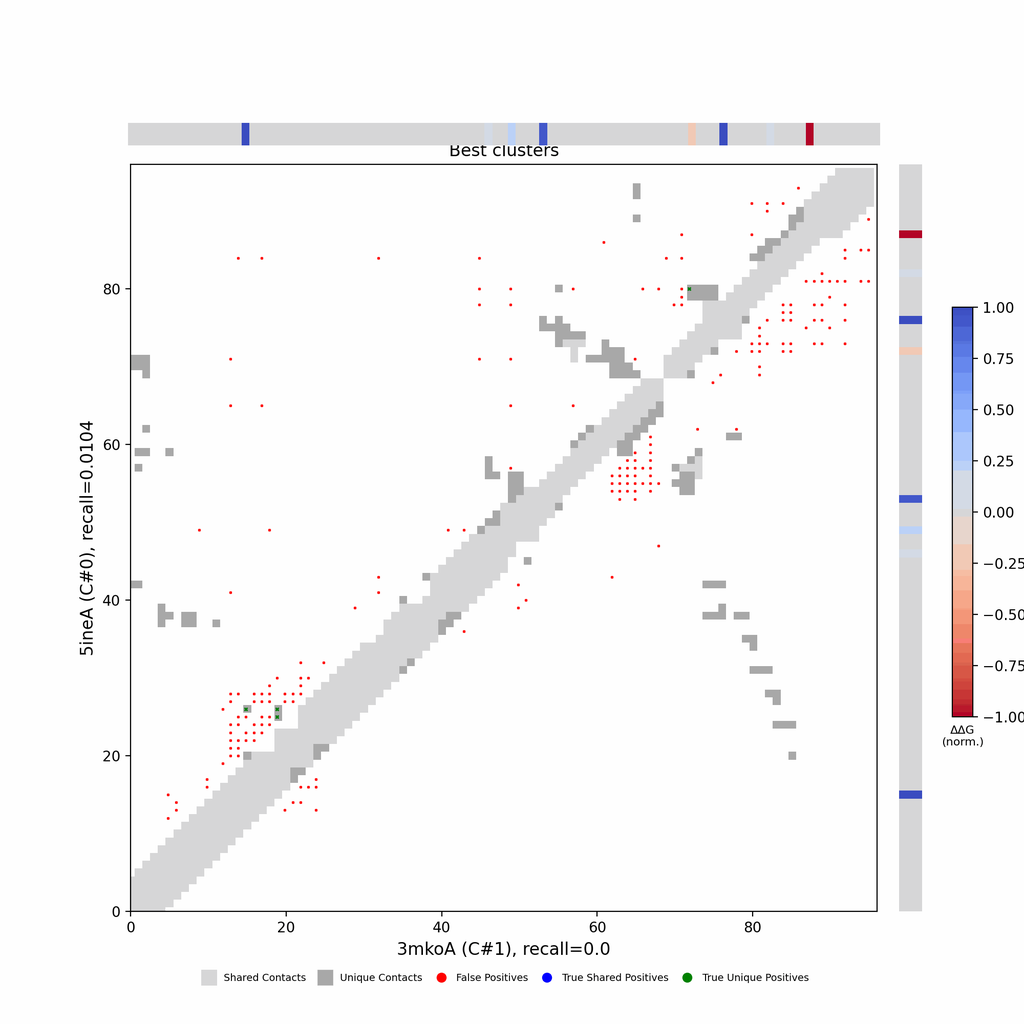

## Figure 5: Per-residue ΔΔG fold-preference contribution

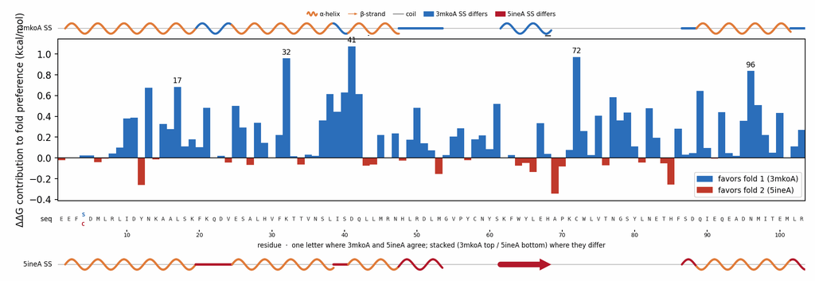

**More figures**

## Figure 6: Deep-MSA contact map panel / Best clusters contact map panel

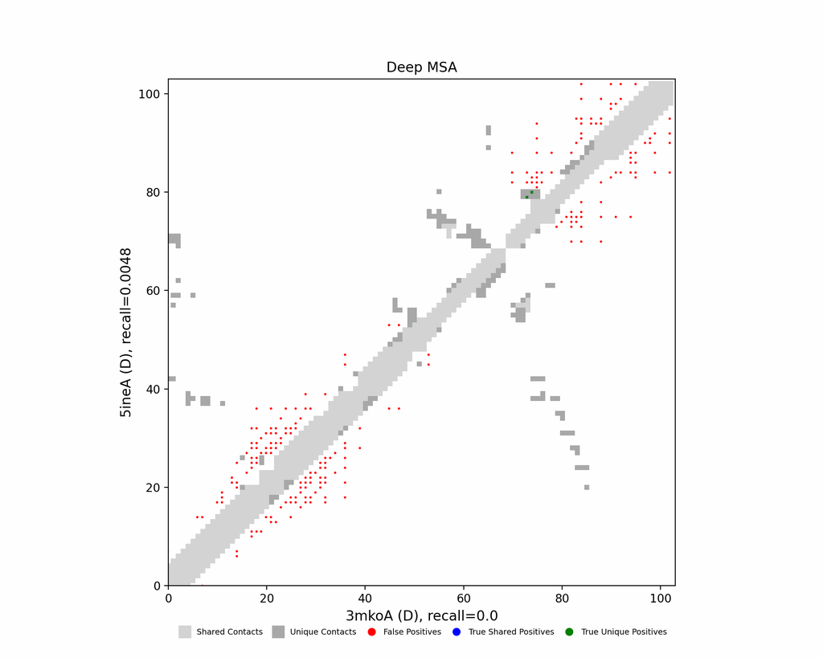

Deep-MSA contact map panel

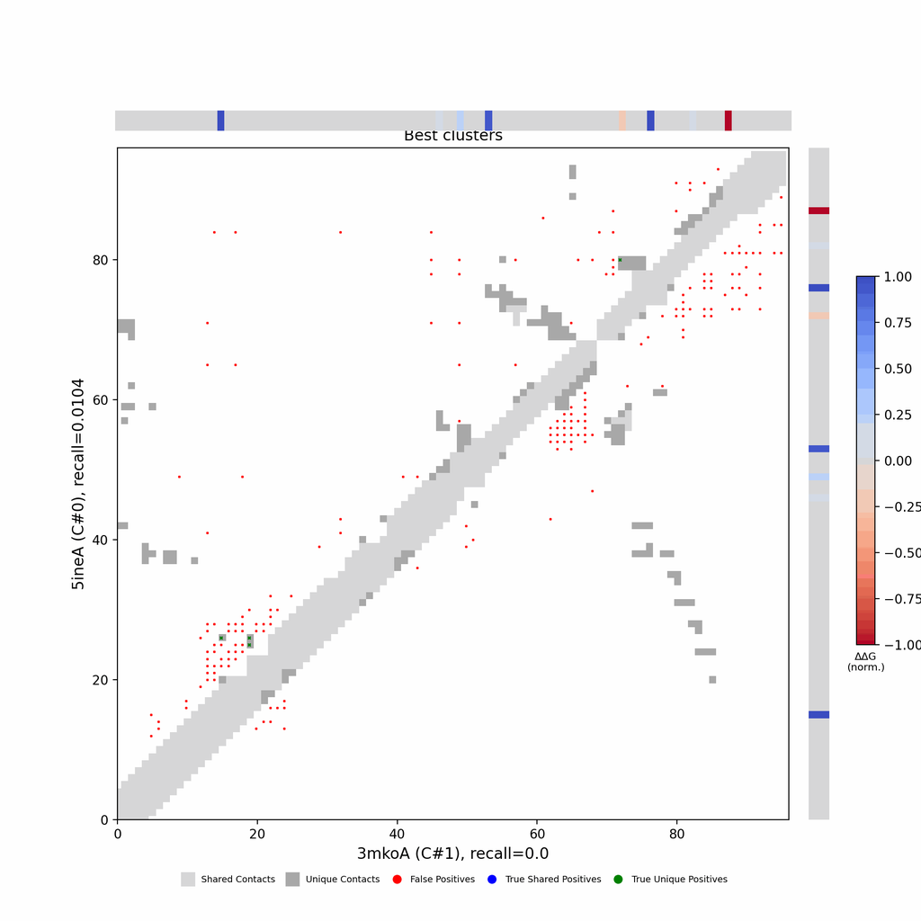

Best clusters contact map panel

## Figure 7: All clusters contact-map mosaic (small multiples).

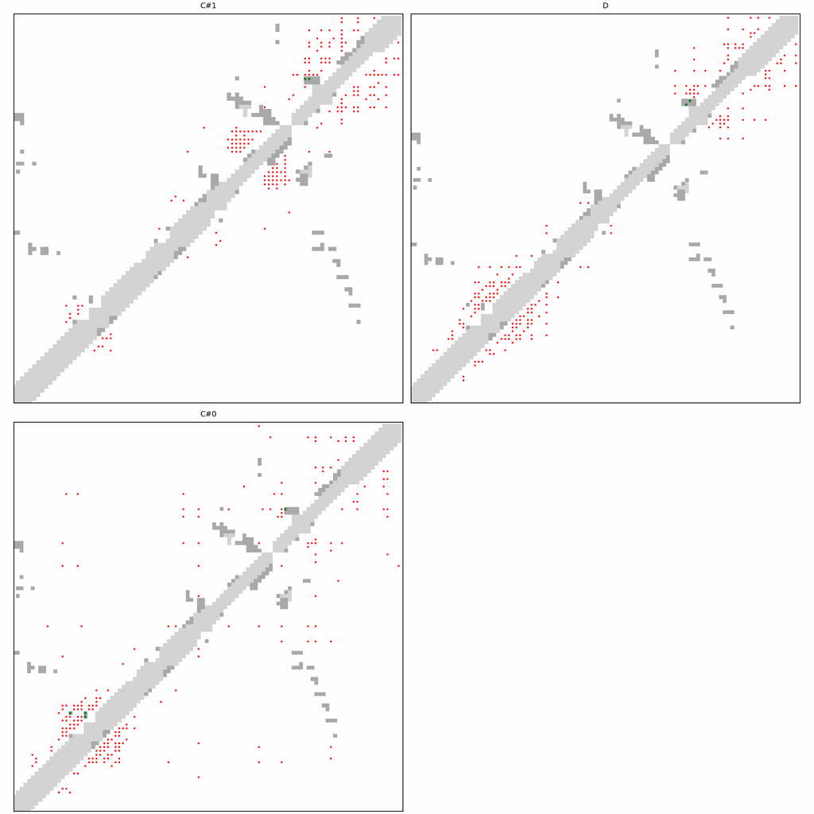

## Figure 8: Phylo null: tree with shuffled cluster fold labels.

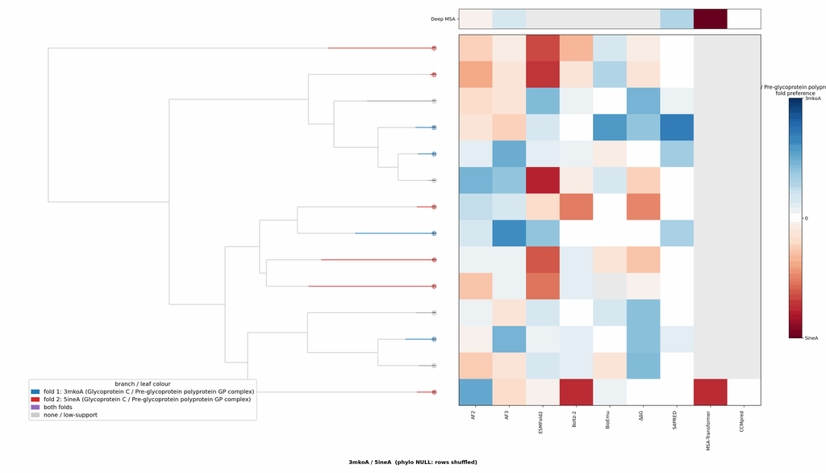

## Cluster metrics table

Per-cluster metrics underlying the figures above.

| cluster | n | neff | AF2_TM1 | AF2_TM2 | AF3_TM1 | AF3_TM2 | RE-MSAT-COM | RE-MSAT1 | RE-MSAT2 | ESM_SEQIDS | ESM_TM1 | ESM_TM2 | ΔΔG_Bias | ΔΔG_Bias_std | ΔΔG_frac_F1 | Boltz2_pref | S4PRED_pref | CCMpred_pref | BioEmu_pref |
| --- | --- | --- | --- | --- | --- | --- | --- | --- | --- | --- | --- | --- | --- | --- | --- | --- | --- | --- | --- |
| Deep | - | - | 0.5 | 0.51 | 0.49 | 0.45 | 0.0 | 0.0 | 0.05 | - | - | - | - | - | - | - | 0.11 | 0.0 | - |
| 000 | 78.0 | 23.0 | 0.52 | 0.2 | 0.32 | 0.25 | 0.0 | 0.0 | 0.0 | 005; 005; 007; 001; 007; 001; 004; 004; 002; 002 | 0.48 ± 0.04 | 0.22 ± 0.05 | 56.08 | 35.39 | 1.0 | -0.55 | -0.26 | 0.0 | 0.03 |
| 001 | 13.0 | 1.0 | 0.29 | 0.23 | 0.32 | 0.18 | - | - | 0.0 | - | - | - | 51.78 | 3.85 | 1.0 | 0.09 | -0.25 | - | - |
| 002 | 13.0 | 10.0 | 0.33 | 0.22 | 0.28 | 0.24 | 0.0 | 0.0 | 0.0 | - | - | - | 97.67 | 4.46 | 1.0 | -0.05 | -0.0 | - | 0.17 |
| 003 | 13.0 | 2.0 | 0.44 | 0.22 | 0.51 | 0.2 | 0.0 | 0.0 | 0.01 | - | - | - | 55.23 | 1.74 | 1.0 | 0.05 | -0.14 | - | 0.03 |
| 004 | 12.0 | 4.0 | 0.5 | 0.21 | 0.46 | 0.21 | - | - | 0.05 | - | - | - | 30.6 | 26.29 | 1.0 | 0.02 | -0.26 | - | 0.09 |
| 005 | - | - | 0.44 | 0.22 | 0.47 | 0.29 | 0.0 | 0.0 | 0.02 | - | - | - | 4.58 | 3.41 | 0.9 | -0.39 | -0.26 | - | 0.04 |
| 006 | 12.0 | 1.0 | 0.23 | 0.2 | 0.27 | 0.19 | 0.0 | 0.0 | 0.01 | - | - | - | 45.2 | 0.86 | 1.0 | -0.02 | -0.25 | - | 0.07 |
| 007 | - | - | 0.28 | 0.2 | 0.28 | 0.18 | - | - | 0.01 | - | - | - | 46.85 | 6.52 | 1.0 | -0.13 | -0.25 | - | 0.06 |
| 008 | 11.0 | 1.0 | 0.52 | 0.35 | 0.53 | 0.39 | - | - | 0.06 | - | - | - | 27.32 | 16.89 | 1.0 | 0.05 | -0.25 | - | 0.06 |
| 009 | 11.0 | 4.0 | 0.35 | 0.18 | 0.36 | 0.29 | 0.0 | 0.0 | 0.0 | - | - | - | 99.34 | 4.79 | 1.0 | 0.0 | -0.25 | - | 0.07 |
| 010 | 11.0 | 6.0 | 0.31 | 0.22 | 0.31 | 0.24 | 0.0 | 0.0 | 0.0 | - | - | - | 104.72 | 4.42 | 1.0 | 0.04 | -0.23 | - | 0.01 |
| 011 | - | - | 0.29 | 0.22 | 0.32 | 0.23 | 0.0 | 0.0 | 0.0 | - | - | - | 101.12 | 8.83 | 1.0 | 0.09 | -0.25 | - | 0.01 |
| 012 | - | - | 0.45 | 0.27 | 0.51 | 0.24 | 0.0 | 0.0 | 0.0 | - | - | - | 56.53 | 1.31 | 1.0 | 0.07 | -0.13 | - | 0.03 |
| 013 | 10.0 | 5.0 | 0.38 | 0.24 | 0.5 | 0.24 | 0.0 | 0.0 | 0.0 | - | - | - | 99.01 | 2.5 | 1.0 | 0.14 | -0.22 | - | 0.02 |